[figure not shown]

[figure not shown]

# Introduction à l’halieutique

Le modèle de production de Schaefer

Laurent Dubroca

24/11/2026

## Plan

1. **Vocabulaire** : stock, biomasse, production, effort, CPUE
2. **Du modèle logistique au modèle de Schaefer** : les équations
3. **Équilibre et points de référence** : MSY, B<sub>MSY</sub>, F<sub>MSY</sub>
4. **Ajuster le modèle aux données** : un exemple réel
5. **Limites et généralisations** : de Fox à SPiCT

**Objectif** : comprendre ce que fait un modèle de production, pour pouvoir le simuler puis l’ajuster sous R dans les TD.

## Vocabulaire

01.

Les mots de la dynamique des stocks

## Le stock et sa biomasse

- **Stock** : unité de gestion d’une population exploitée (espèce, zone)
- **Biomasse** $B$ : masse totale du stock (en tonnes)
- **Production biologique** : variation naturelle de la biomasse, $\frac{dB}{dt}$, résultat de la **reproduction**, de la **croissance** et de la **mortalité naturelle**
- **Productivité** : production par unité de biomasse, $\frac{1}{B}\frac{dB}{dt}$
- **Production excédentaire** (*surplus production*) : la part de la production qui peut être prélevée sans faire baisser le stock

**Équation de Russell (1931)**

$$B_{t+1} = B_t + \underbrace{R_t + G_t - M_t}_{\text{production}} - C_t$$

$R$ recrutement, $G$ croissance, $M$ mortalité naturelle, $C$ captures

Le modèle de Schaefer résume la production en **une seule fonction de $B$**.

## Captures, effort et abondance

- **Capture** $C$ (ou $Y$) : biomasse prélevée par la pêche
- **Effort de pêche** $E$ : quantité de pêche déployée (jours de mer, hameçons…)
- **CPUE** (capture par unité d’effort) : $\text{CPUE} = C / E$
- **Capturabilité** $q$ : part du stock capturée par une unité d’effort
- **Mortalité par pêche** $F = qE$ : taux de prélèvement

$$C = F\,B = q\,E\,B \quad\Rightarrow\quad \text{CPUE} = \frac{C}{E} = q\,B$$

**L’idée clé**

La biomasse d’un stock ne s’observe pas directement.

Un **indice d’abondance** $I = q\,B$ (CPUE commerciale ou campagne scientifique) suit ses **variations relatives**.

## Qu’est-ce qu’un modèle ?

Une **représentation simplifiée** d’un système, qui ne retient que les processus jugés essentiels. *« Tous les modèles sont faux, mais certains sont utiles. »* (G. Box)

**1. Variables et paramètres** (exemple : modèle de Schaefer à temps discret)

$$B_{t+1} = B_t + r\,B_t\left(1 - \frac{B_t}{K}\right) - C_t$$

**Variable** : change avec le temps, porte l’indice $t$.  
**Paramètre** : constant, sans indice, à estimer.

| Symbole | Nature | Signification |
| --- | --- | --- |
| $B_t$ | **variable** (état) | biomasse l’année $t$, calculée par le modèle |
| $C_t$ | **variable** (entrée) | captures l’année $t$, observées |
| $r$ | **paramètre** | taux intrinsèque d’accroissement |
| $K$ | **paramètre** | capacité de charge (biomasse vierge) |

**2. Déterministe ou stochastique ?**

| Déterministe | Stochastique |
| --- | --- |
| pas d’aléa | aléa : $[\ldots]\,e^{\varepsilon_t}$, $\varepsilon_t \sim \mathrm{N}(0, \sigma^2)$ |
| mêmes $r$, $K$, $C_t$ ⇒ **une seule** trajectoire | une trajectoire **différente** à chaque simulation |

**3. Temps continu ou temps discret ?**

| Temps continu | Temps discret |
| --- | --- |
| $\frac{dB}{dt} = r\,B\left(1 - \frac{B}{K}\right) - C$ | $B_t \rightarrow B_{t+1}$ (équation ci-dessus) |
| la biomasse change à chaque instant | pas d’un an, adapté aux données annuelles |

## Du modèle logistique au modèle de Schaefer

02.

Les équations

## Une histoire en trois étapes

- **1838, Verhulst** : croissance **logistique** d’une population limitée par les ressources (Verhulst 1838)
- **1935, Graham** : la pêche est durable si elle prélève l’excédent de production ; celui-ci est maximal à la **moitié** de la capacité de charge (Graham 1935)
- **1954-1957, Schaefer** : un modèle ajustable aux données de **captures et d’effort**, appliqué au **thon albacore** du Pacifique Est (Schaefer 1954; Schaefer 1957)

**Milner B. Schaefer** (1912-1970), halieute américain, directeur scientifique de la Commission interaméricaine du thon tropical (IATTC). Son modèle fonde la notion de **rendement maximal durable** (MSY).

**La croissance logistique de Verhulst**

$$\frac{dB}{dt} = r\,B\left(1 - \frac{B}{K}\right)$$

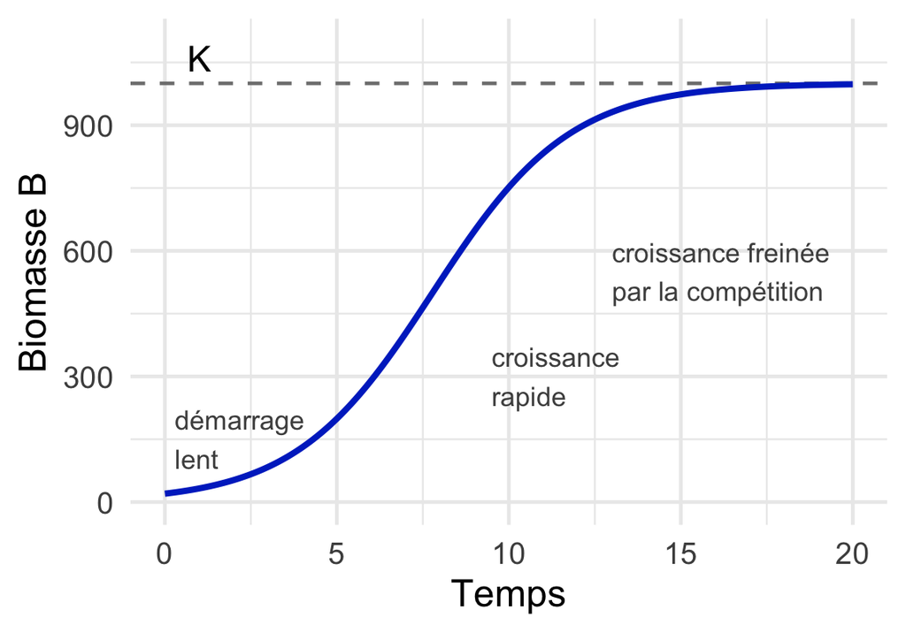

## Point de vocabulaire : $r$ et $K$

**$r$ : taux intrinsèque d’accroissement** de la population (en an<sup>-1</sup>)

Productivité maximale du stock, atteinte quand il est très peu abondant : $r = \frac{1}{B}\frac{dB}{dt}$ quand $B \to 0$.

- Terme consacré en français (Gascuel 2008) ; en anglais *intrinsic rate of natural increase* (Birch 1948)
- À ne pas confondre avec la **croissance individuelle** des poissons : $r$ résume reproduction, croissance et mortalité naturelle

**$K$ : capacité de charge** (ou capacité biotique) du milieu

Biomasse d’équilibre du stock **non exploité**, ou **biomasse vierge** $B_0$.

- En anglais *carrying capacity* ; « capacité biotique du milieu » chez Gascuel (2008)
- C’est un **paramètre estimé** du modèle, pas une propriété mesurable du milieu ; il peut varier avec l’environnement (Chapman et Byron 2018)

## La croissance logistique

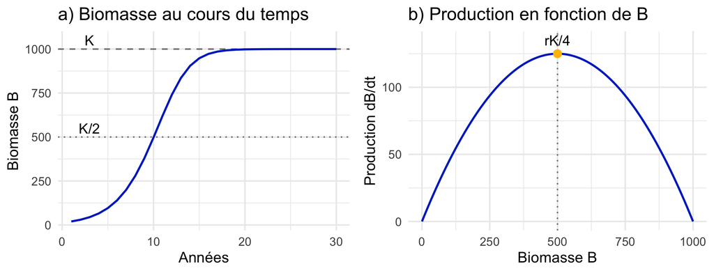

$$\frac{dB}{dt} = r\,B\left(1 - \frac{B}{K}\right)
\qquad \text{Exemple : } r = 0{,}5 \text{ an}^{-1}, \quad K = 1\,000, \quad B_1 = 20$$

## La densité-dépendance

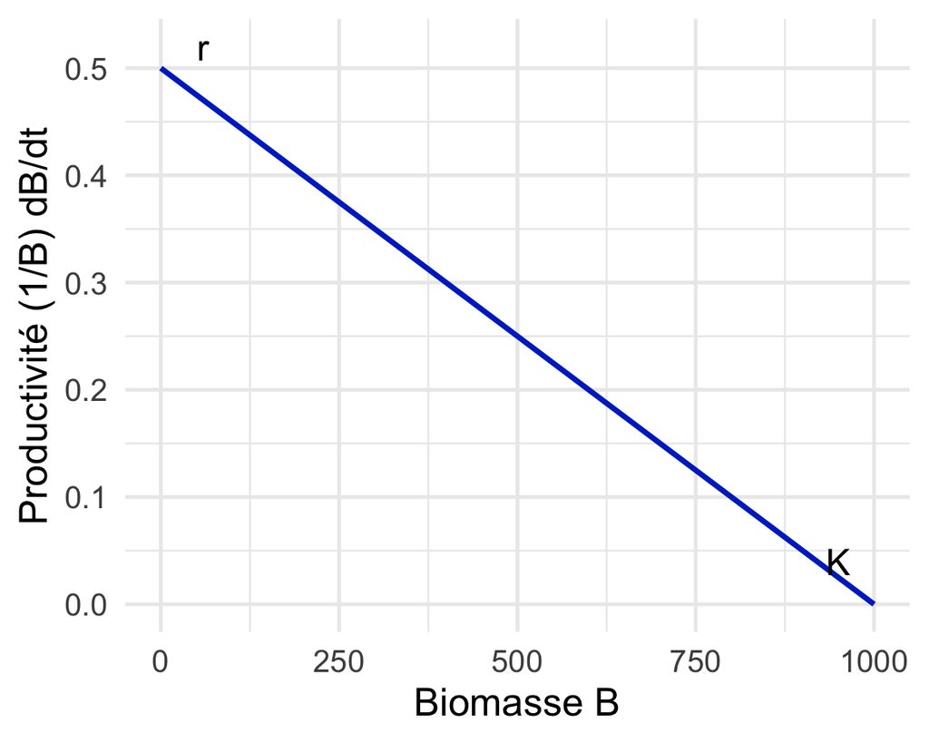

- La **productivité** par unité de biomasse **diminue linéairement** quand la biomasse augmente
- Causes : compétition pour la nourriture et l’espace, croissance individuelle plus lente, cannibalisme, prédation…
- Conséquence : quand la pêche réduit la biomasse, la **productivité par unité de biomasse augmente**
- Mais la **production totale** n’augmente que jusqu’à $K/2$, puis diminue

C’est la **compensation**, une **hypothèse** du modèle, qui rend une pêche durable possible (Laurec et Le Guen 1981; Rose et al. 2001).

## Le modèle de Schaefer

**En temps continu**

$$\frac{dB}{dt} = r\,B\left(1 - \frac{B}{K}\right) - C$$

**En temps discret** (pas annuel), forme utilisée dans les TD

$$B_{t+1} = B_t + r\,B_t\left(1 - \frac{B_t}{K}\right) - C_t$$

**Observation** : $\quad I_t = q\,B_t$

**Exemple de calcul**

$B_t = 10$ t, $r = 0{,}2$, $K = 100$ t, $C_t = 1$ t

$B_{t+1} = 10 + 0{,}2 \times 10 \times (1 - \tfrac{10}{100}) - 1$

$B_{t+1} = 10 + 1{,}8 - 1 = 10{,}8$ t

**Paramètres** : $r$, $K$, $q$ (et $B_1$, la biomasse initiale)

## Le modèle discret peut devenir chaotique

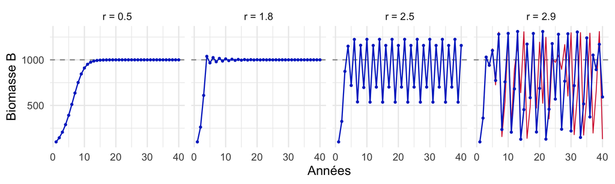

**Chaos** : comportement d’un système **déterministe** (sans aucun aléa) dont la trajectoire est **irrégulière**, ne se répète jamais et reste bornée, et qui est **très sensible aux conditions initiales** : deux trajectoires qui partent de valeurs presque identiques finissent par diverger complètement. À r = 2,9, partir de 101 au lieu de 100 (courbe rouge) donne une autre trajectoire au bout de quelques années : la dynamique devient **imprévisible à long terme**.

Sans pêche, K = 1000, B<sub>1</sub> = 100. Au-delà de r = 2, la biomasse oscille entre 2, 4, 8… valeurs, puis devient chaotique vers r ≈ 2,6 (May 1976).

## Équilibre et points de référence

03.

Le rendement maximal durable

## À l’équilibre

À **mortalité par pêche constante** $F$, le stock tend vers un équilibre où **captures = production**.

**1. Biomasse d’équilibre** : production = captures, puis on divise par $B^*$

$$\begin{aligned}
r\,B^*\left(1 - \frac{B^*}{K}\right) = F\,B^*
&\;\Rightarrow\; r\left(1 - \frac{B^*}{K}\right) = F \\
&\;\Rightarrow\; B^* = K\left(1 - \frac{F}{r}\right)
\end{aligned}$$

**2. Capture équilibrée** : une parabole en $F$

$$C^* = F\,B^* = K\,F - \frac{K}{r}\,F^2$$

**3. Maximum de $C^*$** : on annule la dérivée

$$\frac{dC^*}{dF} = K - \frac{2K}{r}\,F = 0
\;\Rightarrow\;
F_{MSY} = \frac{r}{2}$$

**4. Points de référence** : on remplace $F$ par $F_{MSY}$

|  | Calcul | Résultat | Exemple* |
| --- | --- | --- | --- |
| $F_{MSY}$ | étape 3 | $r/2$ | 0,25 an<sup>-1</sup> |
| $B_{MSY}$ | $K\left(1 - \frac{r/2}{r}\right)$ | $K/2$ | 500 t |
| $MSY$ | $F_{MSY} \times B_{MSY}$ | $rK/4$ | 125 t/an |
| $E_{MSY}$ | $F_{MSY}/q$ (car $F = qE$) | $r/(2q)$ |  |

* $r = 0{,}5$ an<sup>-1</sup>, $K = 1\,000$ t ; $\frac{d^2C^*}{dF^2} = -\frac{2K}{r} < 0$ : c’est bien un maximum.

## Capture et CPUE en fonction de l’effort

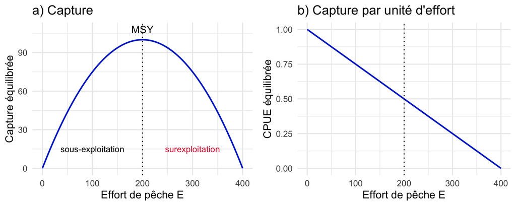

Simulation avec r = 0,4, K = 1000 t, q = 0,001. Au-delà de E<sub>MSY</sub>, **plus d’effort donne moins de captures**.

## Dynamique : effet de la pêche dans le temps

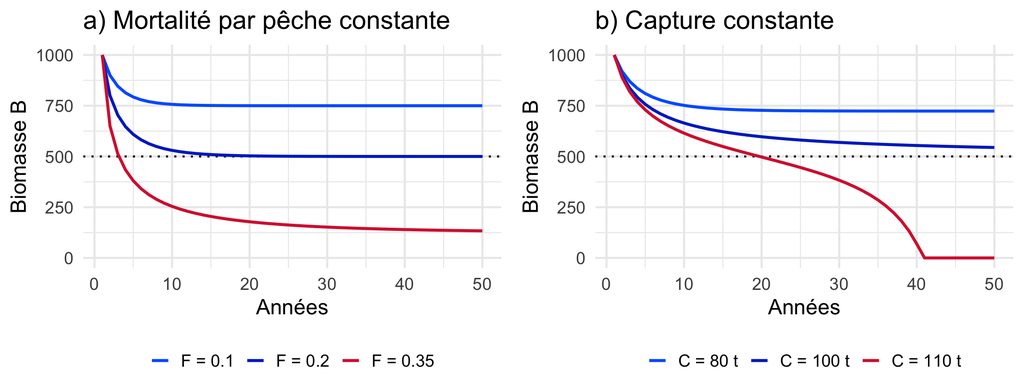

r = 0,4 et K = 1000 t, donc F<sub>MSY</sub> = 0,2, B<sub>MSY</sub> = 500 t et MSY = 100 t. Départ du stock vierge.

## Ajuster le modèle aux données

04.

Estimer r, K et q à partir de séries d’observations

## Données et principe de l’ajustement

**Données nécessaires**

- une série de **captures** $C_t$ (de préférence depuis le début de la pêcherie)
- une série d’**indice d’abondance** $I_t$ (CPUE ou campagne)

**Principe** : chercher les paramètres $(r, K, q, B_1)$ qui rendent l’indice **prédit** $\hat I_t = q\,\hat B_t$ le plus proche de l’indice **observé** :

$$\min_{r,K,q,B_1} \sum_t \left[\ln I_t - \ln(q\,\hat B_t)\right]^2$$

**Trois approches historiques**

- **Équilibre** : suppose le stock à l’équilibre chaque année ; surestime souvent le MSY, **à éviter**
- **Linéarisation** : régression sur des données transformées ; structure d’erreur inadaptée
- **Série temporelle** : simule la dynamique année après année ; la **méthode de référence** (Polacheck et al. 1993)

## Exemple : le germon de l’Atlantique Sud

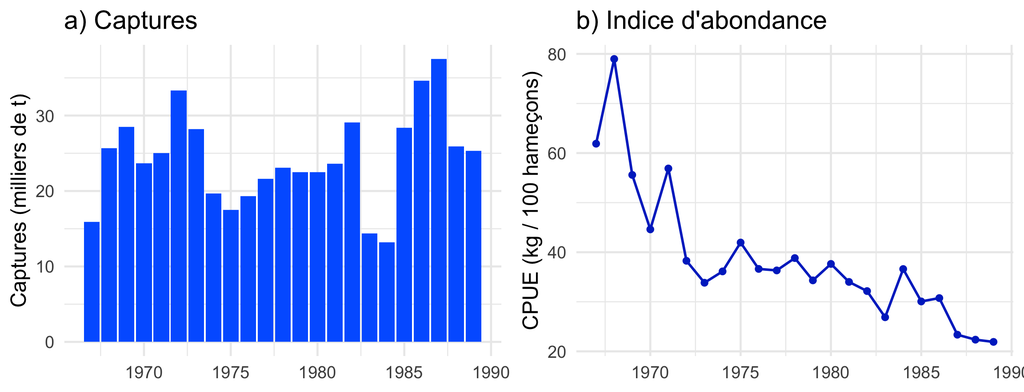

Thon germon (*Thunnus alalunga*), Atlantique Sud, 1967-1989 : captures et CPUE des palangriers (Polacheck et al. 1993)

## Résultat de l’ajustement

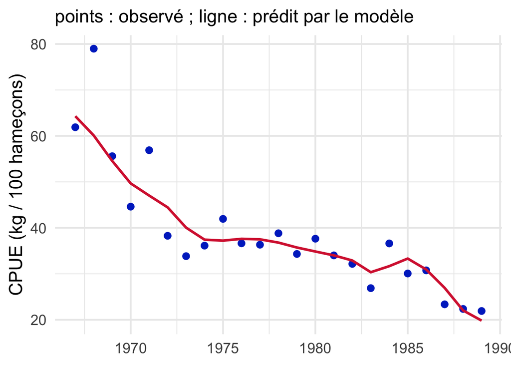

| Paramètre | Estimation |
| --- | --- |
| r | 0.32 |
| K (kt) | 243 |
| q | 0.26 |
| MSY (kt) | 19.5 |
| B<sub>MSY</sub> (kt) | 122 |
| F<sub>MSY</sub> | 0.16 |

Hypothèse : stock vierge en 1967 ($B_1 = K$). Ajustement par `optim()`.

## Diagnostic : diagramme de Kobe

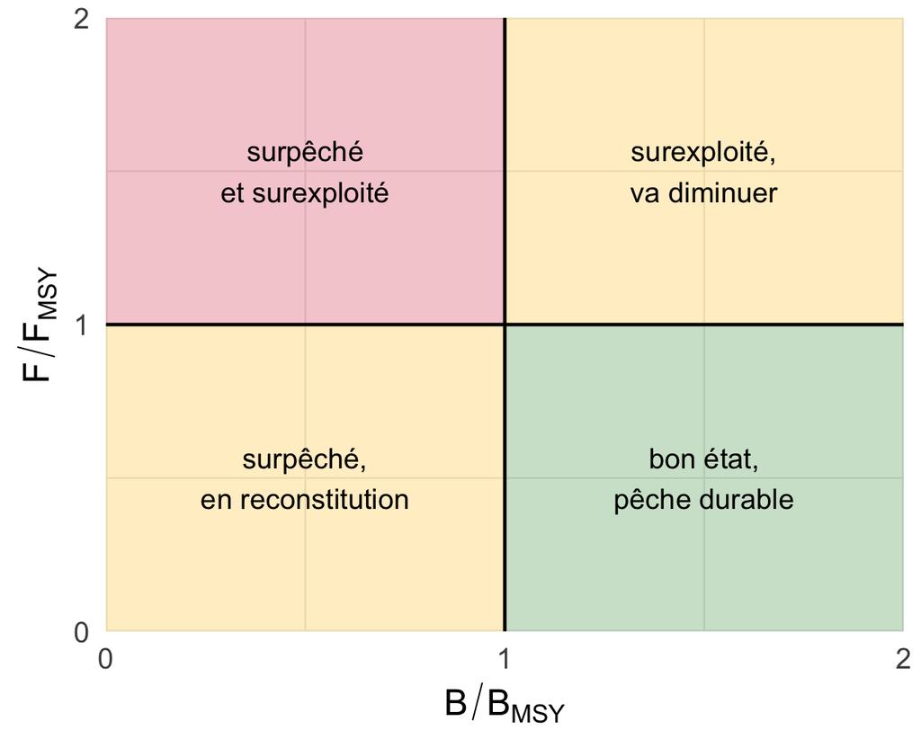

- $B$ : biomasse du stock une année donnée
- $B_{MSY}$ : biomasse qui produit le MSY ($K/2$ chez Schaefer)
- $F$ : mortalité par pêche ($F = C/B$)
- $F_{MSY}$ : mortalité par pêche qui produit le MSY ($r/2$)

| Couleur | État | Diagnostic |
| --- | --- | --- |
| vert | $B \geq B_{MSY}$, $F \leq F_{MSY}$ | bon état, pêche durable |
| jaune (bas) | $B < B_{MSY}$, $F \leq F_{MSY}$ | surpêché, en reconstitution |
| jaune (haut) | $B \geq B_{MSY}$, $F > F_{MSY}$ | surexploité, va diminuer |
| rouge | $B < B_{MSY}$, $F > F_{MSY}$ | surpêché et surexploité |

Format « quatre quadrants rouge-jaune-vert » adopté par les cinq organisations thonières à Kobe (Japon) en 2007 (Joint Meeting of Tuna RFMOs 2007; Maunder et Aires-da-Silva 2011).

## Diagnostic : l’état du stock

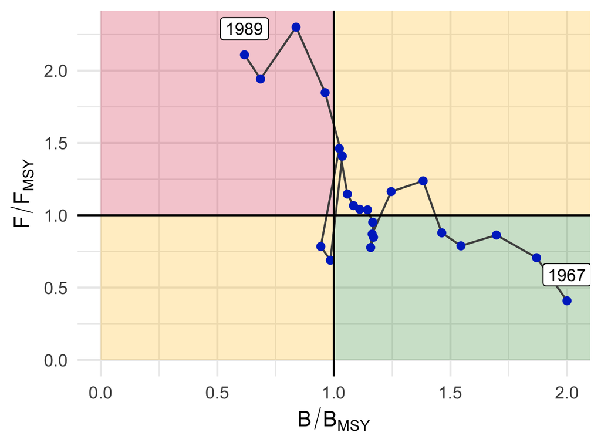

**Diagramme de Kobe**

- **vert** : stock en bon état, pêche durable
- **rouge** : stock **surpêché** ($B < B_{MSY}$) et **surexploité** ($F > F_{MSY}$)

En 1989 : $B/B_{MSY} \approx$ 0.62 et $F/F_{MSY} \approx$ 2.11

## D’autres exemples d’utilisation

- **Thon albacore, Pacifique Est** : premier usage du modèle pour recommander des limites de capture (Schaefer 1957)
- **Thonidés et requins** : les commissions thonières (CICTA, CTOI…) utilisent encore des modèles de production (Winker et al. 2018)
- **Stocks pauvres en données** : le CIEM utilise SPiCT pour estimer F/F<sub>MSY</sub> et B/B<sub>MSY</sub> quand on n’a pas de données par âge (Pedersen et Berg 2017)
- **Pêcheries tropicales** en développement (Gascuel 2008)

**Dans le TD 6**

Ajustement du modèle à **l’espèce de Manche Est choisie au TD 3** :

- captures : débarquements français (SIH)
- indice : campagne scientifique **CGFS** (Ifremer)
- outils : les fonctions écrites aux TD 4 et 5

## Limites et généralisations

05.

De Fox à SPiCT

## Les limites du modèle de Schaefer

- **Pas de structure en âge** : ignore les variations du recrutement et la sélectivité des engins
- **Paramètres constants** : $r$ et $K$ ne varient pas avec l’environnement
- **Capturabilité constante** : $I = qB$ est souvent faux pour une CPUE commerciale
- **Forme imposée** : $B_{MSY}$ toujours égal à $K/2$
- **Besoin de contraste** : si la série ne montre qu’un déclin (*one-way trip*), $r$ et $K$ sont mal estimés (Hilborn et Walters 1992)

**Ressources stables ou instables**

Le modèle convient aux **ressources stables** (recrutement peu variable : gadidés, grands pélagiques).

Il convient mal aux **ressources instables** (petits pélagiques à recrutement très variable) (Gascuel 2008).

## Changer la forme de la courbe : Fox et Pella-Tomlinson

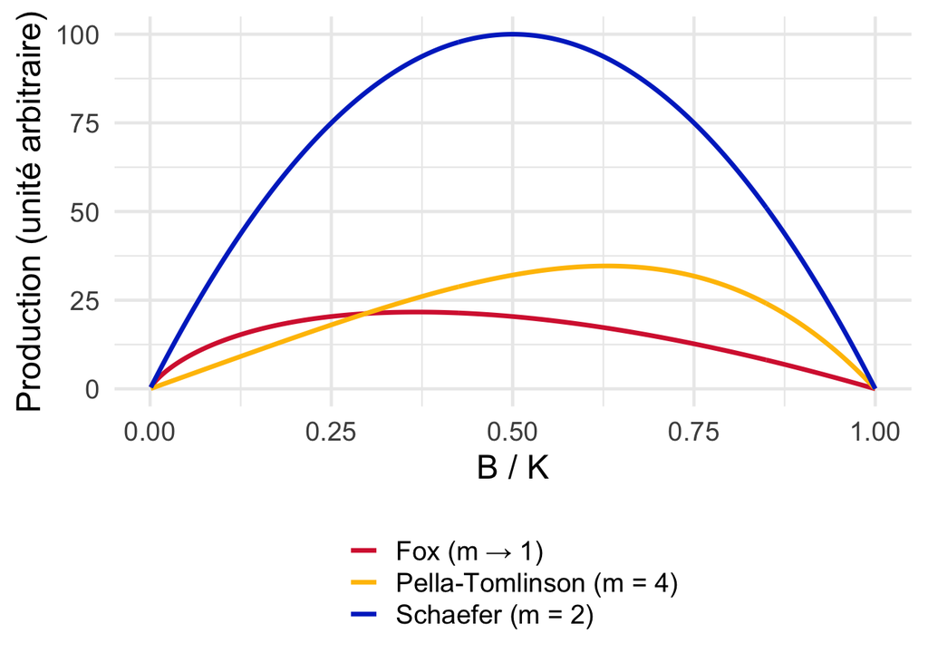

**Modèle généralisé** (Pella et Tomlinson 1969) :

$$\frac{dB}{dt} = \frac{r}{m-1}\,B\left[1 - \left(\frac{B}{K}\right)^{m-1}\right] - C$$

- $m = 2$ : Schaefer, $B_{MSY} = K/2$
- $m \to 1$ : Fox, $B_{MSY} = K/e \approx 0{,}37\,K$ (Fox 1970)
- $m > 2$ : $B_{MSY} > K/2$

Courbes mises à l’échelle pour comparer leurs formes.

## Les modèles de production aujourd’hui

- **Modèles espace d’états** : séparent l’**erreur de processus** (variabilité réelle du stock) et l’**erreur d’observation** (bruit des indices)
- **Approche bayésienne** : intègre des connaissances *a priori* sur $r$ ou $K$ (Meyer et Millar 1999)
- **SPiCT** : temps continu, plusieurs indices, incertitude sur l’état du stock ; utilisé par le CIEM (Pedersen et Berg 2017)
- **JABBA** : bayésien, utilisé pour les thons et les requins (Winker et al. 2018)
- **CMSY** : à partir des seules captures et d’hypothèses sur la résilience (Froese et al. 2017)

**Et au-delà**

Les stocks bien suivis sont évalués par des modèles **structurés en âge ou en taille** (analyse des cohortes, modèles statistiques intégrés).

Les **modèles écosystémiques** intègrent les interactions entre espèces et l’environnement.

## À retenir

- Le modèle de Schaefer décrit la **biomasse totale** d’un stock avec deux paramètres biologiques : $r$ et $K$
- La **densité-dépendance** rend une pêche durable possible : un stock pêché est plus productif **par unité de biomasse** (compensation)
- À l’équilibre : $MSY = rK/4$, $B_{MSY} = K/2$, $F_{MSY} = r/2$
- Au-delà de $F_{MSY}$, **plus d’effort donne moins de captures** à long terme
- On l’ajuste à une série de **captures** et d’**indice d’abondance** en minimisant l’écart entre indice observé et prédit
- Ses limites ont conduit à des modèles plus généraux (Pella-Tomlinson, SPiCT, JABBA), qui gardent les mêmes concepts

## Vers les TD

| TD | Contenu | Notions du cours |
| --- | --- | --- |
| **TD 4** `04_modele_theorie_application` | programmer le modèle ; effet de $r$ et de $K$ ; chaos ; captures constantes et MSY | équations, densité-dépendance, scénarios, points de référence |
| **TD 5** `04_modele_ajustement_application` | ajuster une régression puis le modèle de Schaefer avec `optim()` : données simulées, puis germon | ajustement, indice d’abondance, points de référence, diagnostic |
| **TD 6** `04_modele_ajustementbis_application` | ajuster le modèle à une espèce de Manche Est : débarquements et indice CGFS ; hypothèse sur $r$ ; diagnostic | application réelle, indice de campagne, limites |

Package R nécessaire : **ggplot2** seulement. Les fonctions du modèle sont écrites au TD 4 et réutilisées aux TD 5 et 6.

## Références

Birch, L. C. 1948. « The intrinsic rate of natural increase of an insect population ». *Journal of Animal Ecology* 17 (1): 15‑26. https://doi.org/10.2307/1605.

Chapman, Eric J., et Carrie J. Byron. 2018. « The flexible application of carrying capacity in ecology ». *Global Ecology and Conservation* 13: e00365. https://doi.org/10.1016/j.gecco.2017.e00365.

Fox, Jr., William W. 1970. « An Exponential Surplus-Yield Model for Optimizing Exploited Fish Populations ». *Transactions of the American Fisheries Society* 99 (1): 80‑88. https://doi.org/10.1577/1548-8659(1970)99<80:AESMFO>2.0.CO;2.

Froese, Rainer, Nazli Demirel, Gianpaolo Coro, Kristin M. Kleisner, et Henning Winker. 2017. « Estimating Fisheries Reference Points from Catch and Resilience ». *Fish and Fisheries* 18 (3): 506‑26. https://doi.org/10.1111/faf.12190.

Gascuel, D. 2008. *Dynamique Des Populations et Gestion Des Stocks Halieutiques - Support de Cours*. Agrocampus Ouest / Campus numérique ENVAM.

Graham, Michael. 1935. « Modern Theory of Exploiting a Fishery, and Application to North Sea Trawling ». *Journal du Conseil International pour l’Exploration de la Mer* 10 (3): 264‑74. https://doi.org/10.1093/icesjms/10.3.264.

Haddon, Malcolm. 2020. *Using R for Modelling and Quantitative Methods in Fisheries*. The R Series. Chapman; Hall/CRC. https://doi.org/10.1201/9781003032601.

Hilborn, Ray, et Carl J. Walters. 1992. *Quantitative Fisheries Stock Assessment: Choice, Dynamics and Uncertainty*. Chapman; Hall. https://doi.org/10.1007/978-1-4615-3598-0.

Hutchings, Jeffrey A. 2000. « Collapse and recovery of marine fishes ». *Nature* 406 (6798): 882‑85. https://doi.org/10.1038/35022565.

Joint Meeting of Tuna RFMOs. 2007. *Course of Actions for RFMOs from the Kobe meeting of joint tuna RFMOs*. Kobe (Japon), 26 janvier 2007. Reproduit dans IOTC-2007-S11-INF05. https://iotc.org/sites/default/files/documents/2020/03/IOTC-2007-S11-INF05_-_kobe.pdf.

Laurec, Alain, et Jean-Claude Le Guen. 1981. *Dynamique des populations marines exploitées. Tome 1 : Concepts et modèles*. Rapports scientifiques et techniques du CNEXO 45. Centre National pour l’Exploitation des Océans (CNEXO).

Lorenzen, Kai, et Katja Enberg. 2002. « Density-dependent growth as a key mechanism in the regulation of fish populations: evidence from among-population comparisons ». *Proceedings of the Royal Society of London. Series B: Biological Sciences* 269 (1486): 49‑54. https://doi.org/10.1098/rspb.2001.1853.

Maunder, Mark N., et Alexandre Aires-da-Silva. 2011. *Evaluation of the Kobe plot and strategy matrix and their application to tuna in the EPO*. SAC-02-11. Inter-American Tropical Tuna Commission, Scientific Advisory Committee. https://www.iattc.org/Meetings/Meetings2011/SAC-02/Docs/_English/SAC-02-11_Evaluation-of-Kobe-plot-and-matrix.pdf.

May, Robert M. 1976. « Simple Mathematical Models with Very Complicated Dynamics ». *Nature* 261 (5560): 459‑67. https://doi.org/10.1038/261459a0.

Meyer, Renate, et Russell B. Millar. 1999. « BUGS in Bayesian Stock Assessments ». *Canadian Journal of Fisheries and Aquatic Sciences* 56 (6): 1078‑87. https://doi.org/10.1139/f99-043.

Pedersen, Martin W, et Casper W Berg. 2017. « A Stochastic Surplus Production Model in Continuous Time ». *Fish and Fisheries* 18 (2): 226‑43. https://doi.org/10.1111/faf.12174.

Pella, Jerome J., et Patrick K. Tomlinson. 1969. « A Generalized Stock Production Model ». *Bulletin of the Inter-American Tropical Tuna Commission* 13 (3): 419‑96.

Polacheck, Tom, Ray Hilborn, et André E. Punt. 1993. « Fitting Surplus Production Models: Comparing Methods and Measuring Uncertainty ». *Canadian Journal of Fisheries and Aquatic Sciences* 50 (12): 2597‑607. https://doi.org/10.1139/f93-284.

Rose, Kenneth A., James H. Cowan, Kirk O. Winemiller, Ransom A. Myers, et Ray Hilborn. 2001. « Compensatory density dependence in fish populations: importance, controversy, understanding and prognosis ». *Fish and Fisheries* 2 (4): 293‑327. https://doi.org/10.1046/j.1467-2960.2001.00056.x.

Schaefer, M. B. 1957. « A Study of the Dynamics of the Fishery for Yellowfin Tuna in the Eastern Tropical Pacific Ocean. » *Bulletin, Inter-American Tropical Tuna Commission* 2 (6): 247‑85.

Schaefer, Milner B. 1954. « Some Aspects of the Dynamics of Populations Important to the Management of the Commercial Marine Fisheries ». *Bulletin of the Inter-American Tropical Tuna Commission* 1 (2): 27‑56.

Thorson, James T., Jason M. Cope, Trevor A. Branch, et Olaf P. Jensen. 2012. « Spawning Biomass Reference Points for Exploited Marine Fishes, Incorporating Taxonomic and Body Size Information ». *Canadian Journal of Fisheries and Aquatic Sciences* 69 (9): 1556‑68. https://doi.org/10.1139/f2012-077.

Verhulst, Pierre-François. 1838. « Notice sur la loi que la population suit dans son accroissement ». *Correspondance mathématique et physique* 10: 113‑21.

Winker, Henning, Felipe Carvalho, et Maia Kapur. 2018. « JABBA: Just Another Bayesian Biomass Assessment ». *Fisheries Research* 204: 275‑88. https://doi.org/10.1016/j.fishres.2018.03.010.